# Identify compromised artifacts with HCP Terraform

- 12min
- |
- HCP
- Packer
- Terraform

When you query an artifact fingerprint from HCP Packer, you want to be confident that it is not compromised or outdated. The *data source artifact validation* HCP Terraform run task scans your Terraform resources for references to `hcp_packer_version` and `hcp_packer_artifact` data sources. Once it detects a referenced data resource, it will warn you if it retrieves a revoked artifact version or an artifact version scheduled for revocation. This scanning is available for all HCP Packer users.

Note

HCP Terraform **Free** Edition includes one run task integration that you can apply to up to ten workspaces. Refer to [HCP Terraform pricing](https://www.hashicorp.com/products/terraform/pricing) for details.

Since it relies on the HCP Packer data sources to validate the artifact fingerprints, data source artifact validation supports all Terraform resources. The run task also has paid *resource artifact validation*, which currently only supports this [list of resources](https://developer.hashicorp.com/hcp/docs/packer/manage-image-use/terraform-cloud-run-tasks#supported-resources). The paid validation feature checks artifacts referenced by hard-coded artifact fingerprints.

Note

Scheduled revocation is an [HCP Packer Standard tier](https://cloud.hashicorp.com/products/packer/pricing) feature.

In this tutorial, you will use the HCP Terraform run task for HCP Packer to prevent your Terraform configuration from referencing revoked artifact versions. You will first associate the run task with an HCP Terraform workspace, then test the run task against configuration that includes a revoked version.

## Prerequisites

This tutorial assumes that you are familiar with:

- **The standard Packer and HCP Packer workflows**. If you are new to Packer, complete the [Get Started](https://developer.hashicorp.com/packer/tutorials/aws-get-started) tutorials first. If you are new to HCP Packer, complete the [Get Started HCP Packer](https://developer.hashicorp.com/packer/tutorials/hcp-get-started) tutorials first.
- **The Terraform and HCP Terraform plan/apply workflows**. If you're new to Terraform itself, refer first to the Getting Started tutorials. If you are new to HCP Terraform, refer to the Get Started - HCP Terraform tutorials.

To follow along with this tutorial, you will need:

In addition, you must have an HCP Terraform run task integrated with HCP Packer. If you do not have one set up, follow the [Set Up HCP Terraform Run Task for HCP Packer](https://developer.hashicorp.com/packer/tutorials/hcp/setup-hcp-terraform-run-task) tutorial.

### Create and set HCP service principal ID and key

Log into [HCP Packer](https://portal.cloud.hashicorp.com/services/packer/landing). Select **Access control (IAM)** from the sidebar menu, then click **Service principals**.

Create a service principal named `packer` with the **Contributor** role.

Once you create the service principal, HCP shows you a detailed overview page. Click **Keys** in the left navigation bar, then click **Generate key** to create a client ID and secret.

Copy and save the client ID and secret; you will not be able to retrieve the secret later. You will use these credentials in the next step.

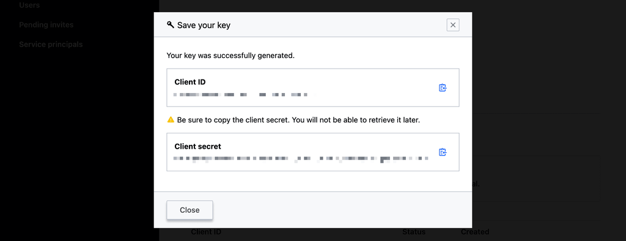

Once you generate the keys for the service principal, set the client ID and secret as environment variables so that Packer can authenticate with HCP.

In your terminal, set an environment variable for the client ID.

```
$ export HCP_CLIENT_ID=
```

Then, set an environment variable for the client secret.

```
$ export HCP_CLIENT_SECRET=
```

Next, navigate to your HCP project settings page to get your project's ID.

[figure not shown]

Use this value to set an environment variable for your project's ID.

```
$ export HCP_PROJECT_ID=
```

### Login to HCP Terraform

In this tutorial, you will use the Terraform CLI to create the HCP Terraform workspace and trigger remote plan and apply runs.

Log in to your HCP Terraform account in your terminal.

```
$ terraform login
Terraform will request an API token for app.terraform.io using your browser.

If login is successful, Terraform will store the token in plain text in
the following file for use by subsequent commands:
    /Users/<USER>/.terraform.d/credentials.tfrc.json

Do you want to proceed?
  Only 'yes' will be accepted to confirm.

  Enter a value:
```

Confirm with a `yes` and follow the workflow in the browser window that automatically opens. Paste the generated API key into your Terminal when prompted. For more detailed instructions on logging in, review the Collaborate using HCP Terraform tutorial.

## Clone repository

In your terminal, clone the [example repository](https://github.com/hashicorp-education/learn-hcp-packer-run-tasks). This repository contains a Packer template that defines an Ubuntu AMI and two directories with configuration that you will use to test the run task.

```
$ git clone https://github.com/hashicorp-education/learn-hcp-packer-run-tasks
```

Navigate to the cloned repository.

```
$ cd learn-hcp-packer-run-tasks
```

## Create artifact version in HCP Packer

Open `ubuntu-focal.pkr.hcl` to review the template. This template will build an Ubuntu 20.04 AMI in the `us-east-2` region. It will also push the metadata to the `learn-packer-run-tasks` bucket in HCP Packer.

ubuntu-focal.pkr.hcl

```
build {
  hcp_packer_registry {
    bucket_name = "learn-packer-run-tasks"
    ## ...
  }
  sources = [
    "source.amazon-ebs.basic-example-east"
  ]
}
```

Initialize your Packer template.

```
$ packer init .
```

Now, build your artifact.

```
$ packer build ubuntu-focal.pkr.hcl
Tracking build on HCP Packer with fingerprint "01HMH2E8ENJR3NB6PBJBT2F69B"
amazon-ebs.basic-example-east: output will be in this color.

==> amazon-ebs.basic-example-east: Prevalidating any provided VPC information
==> amazon-ebs.basic-example-east: Prevalidating AMI Name: packer_AWS_1705675008_v1.0.0
    amazon-ebs.basic-example-east: Found Image ID: ami-03...
## ...
==> Wait completed after 4 minutes 34 seconds

==> Builds finished. The artifacts of successful builds are:
--> amazon-ebs.basic-example-east: AMIs were created:
us-east-2: ami-0c16bec5441261947

--> amazon-ebs.basic-example-east: Published metadata to HCP Packer registry packer/learn-packer-run-tasks/versions/01HMH2E9VE1RQ20E2CTV9SX4ZT
```

In your [HCP dashboard](https://portal.cloud.hashicorp.com), go to the `learn-packer-run-tasks` bucket to confirm Packer pushed the build metadata to HCP Packer.

[figure not shown]

### Create channel and schedule revocation

From the [HCP Packer UI](https://portal.cloud.hashicorp.com), navigate to the **Channels** page. Create a channel named `production` and set it to the first version.

[figure not shown]

Next, go to the **Versions** page. Schedule a revocation date for the first version by clicking on **...**, then **Revoke version**.

Select **Revoke at a future date** and enter the time for 1 minute from your current time. The time is in UTC ([current time in UTC](https://time.is/UTC)). For example, if it is currently `10:00`, enter `10:01`. Then, enter `Assign artifact channel to revoked version` for the revocation reason, then click **Revoke Version** to revoke the version.

You are setting a short revocation window so that your artifact channel uses a revoked artifact to test validation workflows. This is for the educational purposes of the tutorial.

[figure not shown]

## Set up HCP Terraform workspace

Go to the `tf-data-source-validation` directory. This directory contains Terraform configuration that you will use to create an HCP Terraform workspace to test the data source artifact validation run task.

```
$ cd tf-data-source-validation
```

Open `main.tf`. This configuration defines two data sources that retrieve an AMI ID from the `production` channel of the `learn-packer-run-tasks` HCP Packer bucket, and an EC2 instance that uses the image ID returned by the HCP Packer data sources.

tf-data-source-validation/main.tf

```
provider "hcp" {}

provider "aws" {
  region = var.region
}

data "hcp_packer_version" "ubuntu" {
  bucket_name  = "learn-packer-run-tasks"
  channel_name = "production"
}

data "hcp_packer_artifact" "ubuntu_us_east_2" {
  bucket_name         = "learn-packer-run-tasks"
  platform            = "aws"
  version_fingerprint = data.hcp_packer_version.ubuntu.fingerprint
  region              = "us-east-2"
}

resource "aws_instance" "app_server" {
  ami           = data.hcp_packer_artifact.ubuntu_us_east_2.external_identifier
  instance_type = "t2.micro"
  tags = {
    Name = "Learn-HCP-Packer"
  }
}
```

### Update configuration

Open `terraform.tf`. In the `cloud` block, update the `organization` to point to your HCP Terraform organization.

tf-data-source-validation/terraform.tf

```
terraform {
  ## ...

  cloud {
    organization = "hashicorp-training"
    hostname     = "app.terraform.io"

    workspaces {
      name = "learn-hcp-packer-run-tasks-data-source-validation"
    }
  }
}
```

### Create HCP Terraform workspace

Initialize your Terraform configuration. This will create an HCP Terraform workspace named `learn-hcp-packer-run-tasks-data-source-validation` in your HCP Terraform organization.

```
$ terraform init

Initializing HCP Terraform...

Initializing provider plugins...
- Reusing previous version of hashicorp/aws from the dependency lock file
- Installing hashicorp/aws v4.2.0...
- Installed hashicorp/aws v4.2.0 (signed by HashiCorp)

HCP Terraform has been successfully initialized!

You may now begin working with HCP Terraform. Try running "terraform plan" to
see any changes that are required for your infrastructure.

If you ever set or change modules or Terraform Settings, run "terraform init"
again to reinitialize your working directory.
```

Log into the [HCP Terraform UI](https://app.terraform.io) and go to the `learn-hcp-packer-run-tasks-data-source-validation` workspace.

[figure not shown]

### Add AWS and HCP credentials to workspace variables

Go to the **Variables** page.

Warning

Be sure to mark the `AWS_SECRET_ACCESS_KEY` and `HCP_CLIENT_SECRET` as `sensitive`.

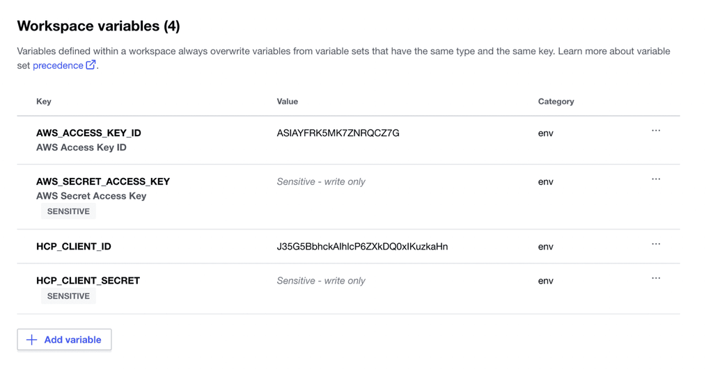

Note

Set a variable for your `AWS_SESSION_TOKEN` if your organization requires it.

### Enable run tasks in workspace

Click on **Settings**, then **Run Tasks**. Under **Available Run Tasks**, click on **HCP-Packer**.

[figure not shown]

HCP Terraform run tasks have two enforcement levels.

1. **Advisory**: If this run task fails, the run will proceed with a warning in the UI.
2. **Mandatory**: If this run task fails, the run will return an error and stop.

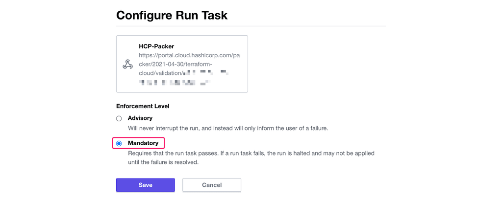

[figure not shown]

## Trigger HCP Terraform run

In your terminal, apply your configuration. After Terraform creates the plan, the run will return an error because the run task failed.

[output not shown]

In HCP Terraform, open the latest run. Notice that Terraform was able to build an execution plan.

The `hcp_packer_artifact` data source will return the artifact satisfying the data source parameters regardless of its revocation status. If the data source references a revoked artifact or an artifact that is scheduled to be revoked, the `revoke_at` attribute is set to the revocation timestamp.

The data source artifact validation run task automatically checks and warns for artifact versions that are revoked or scheduled for revocation.

Click the **Tasks failed** box.

[figure not shown]

The run task failed with the following message:

> Data source artifact validation results: 1 resource scanned. 1 new resource using revoked artifacts. No newer version was found for the revoked artifacts. Use Packer to build compliant artifacts and send information to HCP Packer. When using channels, the channel must be re-assigned to a valid version.

The run task detected that the `aws_instance` resource references the `hcp_packer_artifact` data source. Since the data source references a revoked version and the resource was being created, the run task failed and blocked the deployment of revoked artifacts.

Note

The run task will **only** fail if the configuration uses a revoked artifact for creating new resources. If an existing resource uses a revoked artifact, the run task will succeed but still report that the resource is not compliant.

If the run task determines that a newer version version is available, it will suggest that you use it. If you are the artifact maintainer, you can assign the channel to the newer version.

The **Details** link in the run task output will take you to the HCP Packer dashboard in case you wish to make any changes.

## Restore artifact version

In the HCP Packer dashboard, go to the `learn-packer-run-tasks` bucket and select the revoked version. Click **Manage**, then **Restore version** to restore the revoked version.

[figure not shown]

Confirm the action by clicking on **Restore version**.

## Re-trigger HCP Terraform run

Apply your configuration. When prompted to confirm the apply, press `Enter` to discard the run.

```
$ terraform apply
Running apply in HCP Terraform. Output will stream here. Pressing Ctrl-C
will cancel the remote apply if it's still pending. If the apply started it
will stop streaming the logs, but will not stop the apply running remotely.

Preparing the remote apply...

To view this run in a browser, visit:
https://app.terraform.io/app/hashicorp-training/learn-hcp-packer-run-tasks-data-source-validation/runs/run-REDACTED

Waiting for the plan to start...

Terraform v1.1.6
on linux_amd64
Configuring remote state backend...
Initializing Terraform configuration...

## ...

Plan: 1 to add, 0 to change, 0 to destroy.

## ...

Do you want to perform these actions in workspace "learn-hcp-packer-run-tasks-data-source-validation"?
  Terraform will perform the actions described above.
  Only 'yes' will be accepted to approve.

  Enter a value:

╷
│ Error: Apply discarded.
│
│
```

### Verify artifact validation

In [HCP Terraform](https://app.terraform.io), open the latest run and expand the **Tasks passed** box.

[figure not shown]

The run task passed with the following message:

> Data source artifact validation: 1 resource scanned. All resources are compliant.

The run task parsed the `aws_instance` resource and again detected the reference to the HCP Packer data source. Since you restored the version, your configuration is now valid and the run check passes.

The data source artifact validation **only** validates resources that reference the `hcp_packer_artifact` data source. The Standard tier resource artifact validation run task validates all types of artifact fingerprint references (for example, HCP data source, hard-coded, or external source).

## Next steps

In this tutorial, you used the HCP Terraform run task for HCP Packer to prevent your Terraform configuration from referencing revoked artifact versions.

For more information on topics covered in this tutorial, check out the following resources:

- Complete the [resource artifact validation run task feature](https://developer.hashicorp.com/packer/tutorials/hcp/run-tasks-resource-image-validation) tutorial to learn how to ensure your Terraform configuration uses compliant machine artifacts (even if you hard-code machine artifact fingerprints).
- Read more about the [HCP Terraform run task integration](https://developer.hashicorp.com/hcp/docs/packer/manage-image-use/terraform-cloud-run-tasks) in the HCP Packer documentation.